# **Project - Twitter US Airline Sentiment**

### Data Description:

A sentiment analysis job about the problems of each major U.S. airline. Twitter data was scraped from February of 2015 and contributors were asked to first classify positive, negative, and neutral tweets, followed by categorizing negative reasons (such as "late flight" or "rude service").

### Dataset:

The dataset has the following columns:

- tweet_id
- airline_sentiment
- airline_sentiment_confidence
- negativereason
- negativereason_confidence
- airline
- airline_sentiment_gold
- name
- negativereason_gold
- retweet_count
- text
- tweet_coord
- tweet_created
- tweet_location
- user_timezone

```python
!pip install contractions
```

```python
# Import libraries

import re, string, unicodedata                            # Regex, string, and unicodedata
import contractions                                       # contractions library
from bs4 import BeautifulSoup

import numpy as np
import pandas as pd
import nltk                                               # Natural Language Tool-Kit.

nltk.download('stopwords')                                # Download Stopwords
nltk.download('punkt')
nltk.download('wordnet')

from nltk.corpus import stopwords                         # Stopwords
from nltk.tokenize import word_tokenize, sent_tokenize    # Tokenizer
from nltk.stem.wordnet import WordNetLemmatizer           # Lematizer
import matplotlib.pyplot as plt
import seaborn as sns
```

```python
from google.colab import drive
drive.mount('/content/drive')
```

```python
data = pd.read_csv('drive/My Drive/Tweets.csv')
```

```python
# shape of dataset
data.shape
```

```
(14640, 15)
```

- We have 14,640 rows and 15 columns in our dataset.

```python
data.describe()
```

|  | tweet_id | airline_sentiment_confidence | negativereason_confidence | retweet_count |
| --- | --- | --- | --- | --- |
| count | 1.464000e+04 | 14640.000000 | 10522.000000 | 14640.000000 |
| mean | 5.692184e+17 | 0.900169 | 0.638298 | 0.082650 |
| std | 7.791112e+14 | 0.162830 | 0.330440 | 0.745778 |
| min | 5.675883e+17 | 0.335000 | 0.000000 | 0.000000 |
| 25% | 5.685592e+17 | 0.692300 | 0.360600 | 0.000000 |
| 50% | 5.694779e+17 | 1.000000 | 0.670600 | 0.000000 |
| 75% | 5.698905e+17 | 1.000000 | 1.000000 | 0.000000 |
| max | 5.703106e+17 | 1.000000 | 1.000000 | 44.000000 |

```python
data.head()
```

|  | tweet_id | airline_sentiment | airline_sentiment_confidence | negativereason | negativereason_confidence | airline | airline_sentiment_gold | name | negativereason_gold | retweet_count | text | tweet_coord | tweet_created | tweet_location | user_timezone |
| --- | --- | --- | --- | --- | --- | --- | --- | --- | --- | --- | --- | --- | --- | --- | --- |
| 0 | 570306133677760513 | neutral | 1.0000 | NaN | NaN | Virgin America | NaN | cairdin | NaN | 0 | @VirginAmerica What @dhepburn said. | NaN | 2015-02-24 11:35:52 -0800 | NaN | Eastern Time (US & Canada) |
| 1 | 570301130888122368 | positive | 0.3486 | NaN | 0.0000 | Virgin America | NaN | jnardino | NaN | 0 | @VirginAmerica plus you've added commercials t... | NaN | 2015-02-24 11:15:59 -0800 | NaN | Pacific Time (US & Canada) |
| 2 | 570301083672813571 | neutral | 0.6837 | NaN | NaN | Virgin America | NaN | yvonnalynn | NaN | 0 | @VirginAmerica I didn't today... Must mean I n... | NaN | 2015-02-24 11:15:48 -0800 | Lets Play | Central Time (US & Canada) |
| 3 | 570301031407624196 | negative | 1.0000 | Bad Flight | 0.7033 | Virgin America | NaN | jnardino | NaN | 0 | @VirginAmerica it's really aggressive to blast... | NaN | 2015-02-24 11:15:36 -0800 | NaN | Pacific Time (US & Canada) |
| 4 | 570300817074462722 | negative | 1.0000 | Can't Tell | 1.0000 | Virgin America | NaN | jnardino | NaN | 0 | @VirginAmerica and it's a really big bad thing... | NaN | 2015-02-24 11:14:45 -0800 | NaN | Pacific Time (US & Canada) |

```python
data.info()
```

```
<class 'pandas.core.frame.DataFrame'>
RangeIndex: 14640 entries, 0 to 14639
Data columns (total 15 columns):
 #   Column                        Non-Null Count  Dtype
---  ------                        --------------  -----
 0   tweet_id                      14640 non-null  int64
 1   airline_sentiment             14640 non-null  object
 2   airline_sentiment_confidence  14640 non-null  float64
 3   negativereason                9178 non-null   object
 4   negativereason_confidence     10522 non-null  float64
 5   airline                       14640 non-null  object
 6   airline_sentiment_gold        40 non-null     object
 7   name                          14640 non-null  object
 8   negativereason_gold           32 non-null     object
 9   retweet_count                 14640 non-null  int64
 10  text                          14640 non-null  object
 11  tweet_coord                   1019 non-null   object
 12  tweet_created                 14640 non-null  object
 13  tweet_location                9907 non-null   object
 14  user_timezone                 9820 non-null   object
dtypes: float64(2), int64(2), object(11)
memory usage: 1.7+ MB
```

- negativereason, negativereason_confidence, airline_sentiment_gold, negativereason_gold, tweet_coord, tweet_location, user_timezone columns have missing values.

### 2. Do Exploratory data analysis(EDA) based on the below statement. (9 Marks)

```
  a. Plot the distribution of all tweets among each airline & plot the distribution of sentiment across all the tweets.
  b. Plot the distribution of Sentiment of tweets for each airline & plot the distribution of all the negative reasons.
  c. Plot the word cloud graph of tweets for positive and negative sentiment separately.
```

```python
#Function to create barplots that indicate percentage for each category
def perc_on_bar(feature):
    #Creating a countplot for the feature
    sns.set(rc={'figure.figsize':(20,10)})
    ax=sns.countplot(x=feature, data=data,hue = data['airline_sentiment'])

    total = len(feature) # length of the column
    for p in ax.patches:
        percentage = '{:.1f}%'.format(100 * p.get_height()/total) # percentage of each class of the category
        x = p.get_x() + p.get_width() / 2 - 0.25 # width of the plot
        y = p.get_y() + p.get_height()           # hieght of the plot
        ax.annotate(percentage, (x, y), size = 10) # annotate the percantage

    plt.show() # show the plot
```

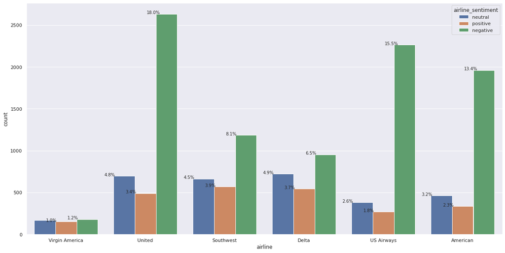

```python
# a. Plot the distribution of all tweets among each airline & plot the distribution of sentiment across all the tweets.
perc_on_bar(data['airline'])
```

- All the airline companies have **negative sentiment** higher than positive and neutral sentiment.

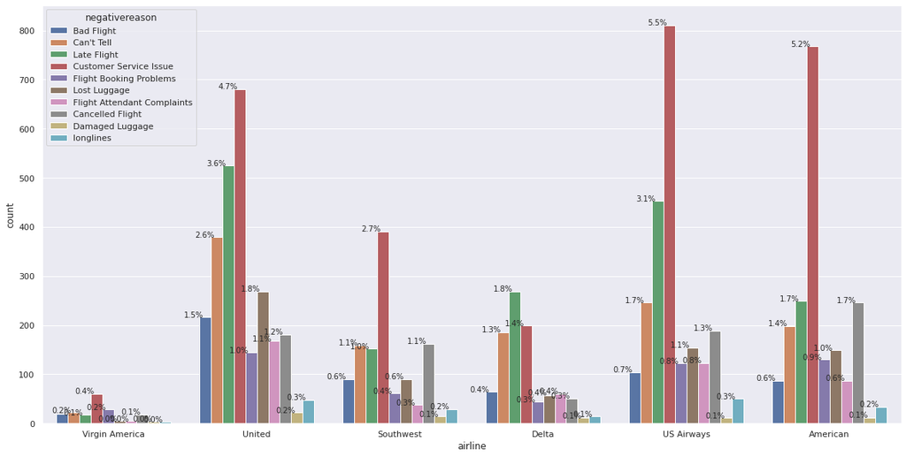

```python
# b. Plot the distribution of Sentiment of tweets for each airline & plot the distribution of all the negative reasons.
sns.set(rc={'figure.figsize':(20,10)})
ax=sns.countplot(x=data['airline'], data=data['airline_sentiment'], hue=data['negativereason'])
total = len(data['airline']) # length of the column
for p in ax.patches:
    percentage = '{:.1f}%'.format(100 * p.get_height()/total) # percentage of each class of the category
    x = p.get_x() + p.get_width() / 2 - 0.15 # width of the plot
    y = p.get_y() + p.get_height()           # hieght of the plot
    ax.annotate(percentage, (x, y), size = 10) # annotate the percantage

plt.show() # show the plot
```

- Virgin America, United, Southwest, US Airways, and American airline company have **customer service issue** negative sentiment higher than others negative sentiment.
- Delta more likely customers complain about **late flight**

```python
#  c. Plot the word cloud graph of tweets for positive and negative sentiment separately.
plot_data = data.copy()
plot_data['text'] = data.apply(lambda row: nltk.word_tokenize(row['text']), axis=1) # Tokenization of data

import wordcloud
def show_wordcloud(df, title):
    text = ' '.join(df['text'].astype(str).tolist())                 # Converting Summary column into list
    stopwords = set(wordcloud.STOPWORDS)                                  # instantiate the stopwords from wordcloud

    fig_wordcloud = wordcloud.WordCloud(stopwords=stopwords,background_color='white',          # Setting the different parameter of stopwords
                    colormap='viridis', width=800, height=600).generate(text)

    plt.figure(figsize=(14,11), frameon=True)
    plt.imshow(fig_wordcloud)
    plt.axis('off')
    plt.title(title, fontsize=30)
    plt.show()
```

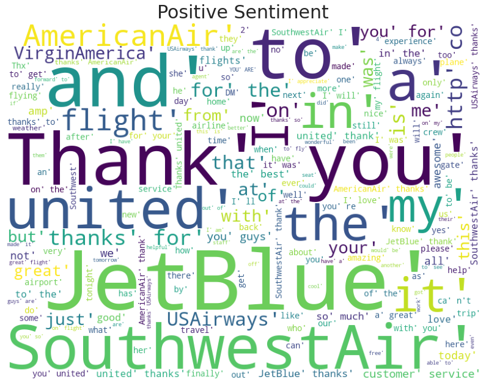

```python
plot_data_positive = plot_data[plot_data['airline_sentiment']=='positive']
show_wordcloud(plot_data_positive,'Positive Sentiment')
```

- We can see **SouthwestAir, JetBlue, United** most frequent words which tweeted by customers as positive sentiment.

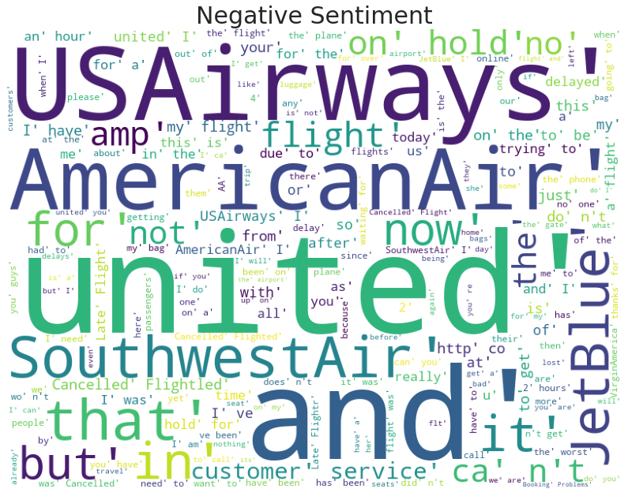

```python
plot_data_negative = plot_data[plot_data['airline_sentiment']=='negative']
show_wordcloud(plot_data_negative,'Negative Sentiment')
```

- We can see **United,USAirway, AmericanAir, SouthwestAir** are the most frequent words shown in negative sentiment.

### 3. Understand of data columns: (3 Marks)

```
 a. Drop all other columns except “text” and “airline_sentiment”.
 b. Check the shape of the data.
 c. Print the first 5 rows of data.
```

```python
data1 = data.copy()
data1.drop(data1.columns.difference(['text','airline_sentiment']), 1, inplace=True)
```

```python
data1.shape
```

```
(14640, 2)
```

```python
data1.head()
```

|  | airline_sentiment | text |
| --- | --- | --- |
| 0 | neutral | @VirginAmerica What @dhepburn said. |
| 1 | positive | @VirginAmerica plus you've added commercials t... |
| 2 | neutral | @VirginAmerica I didn't today... Must mean I n... |
| 3 | negative | @VirginAmerica it's really aggressive to blast... |
| 4 | negative | @VirginAmerica and it's a really big bad thing... |

### 4. Text pre-processing: Data preparation. (12 Marks)

NOTE:- Each text pre-processing step should be mentioned in the notebook separately.

```
 a. Html tag removal.
 b. Tokenization.
 c. Remove the numbers.
 d. Removal of Special Characters and Punctuations.
 e. Removal of stopwords
 f. Conversion to lowercase.
 g. Lemmatize or stemming.
 h. Join the words in the list to convert back to text string in the data frame. (So that each row
      contains the data in text format.)
 i. Print the first 5 rows of data after pre-processing.
```

```python
# a. HTML tag removal
def strip_html(text):
  soup = BeautifulSoup(text, 'html.parser')
  return soup.get_text()

data1['text'] = data1['text'].apply(lambda x: strip_html(x))
data1.head()
```

|  | airline_sentiment | text |
| --- | --- | --- |
| 0 | neutral | @VirginAmerica What @dhepburn said. |
| 1 | positive | @VirginAmerica plus you've added commercials t... |
| 2 | neutral | @VirginAmerica I didn't today... Must mean I n... |
| 3 | negative | @VirginAmerica it's really aggressive to blast... |
| 4 | negative | @VirginAmerica and it's a really big bad thing... |

```python
# replace contractions in string (e.g replace I'm -> I am) and so on.
def replace_contractions(text):
    return contractions.fix(text)
data1['text'] = data1['text'].apply(lambda x: replace_contractions(x))
data1.head()
```

|  | airline_sentiment | text |
| --- | --- | --- |
| 0 | neutral | @VirginAmerica What @dhepburn said. |
| 1 | positive | @VirginAmerica plus you have added commercials... |
| 2 | neutral | @VirginAmerica I did not today... Must mean I ... |
| 3 | negative | @VirginAmerica it is really aggressive to blas... |
| 4 | negative | @VirginAmerica and it is a really big bad thin... |

```python
# b. Tokenization
data1['text'] = data1.apply(lambda row: nltk.word_tokenize(row['text']), axis=1) # Tokenization of data
data1.head()
```

|  | airline_sentiment | text |
| --- | --- | --- |
| 0 | neutral | [@, VirginAmerica, What, @, dhepburn, said, .] |
| 1 | positive | [@, VirginAmerica, plus, you, have, added, com... |
| 2 | neutral | [@, VirginAmerica, I, did, not, today, ..., Mu... |
| 3 | negative | [@, VirginAmerica, it, is, really, aggressive,... |
| 4 | negative | [@, VirginAmerica, and, it, is, a, really, big... |

```python
# c. Remove numbers
def remove_numbers(words):
  new_words = []
  for word in words:
    new_word = re.sub(r'\d', '', word)
    if new_word != '':
      new_words.append(new_word)
  return new_words

# d. Remove of Special Characters and Punctuations.
def remove_special_characters_punctuation(words):
  new_words =[]
  for word in words:
    new_word = re.sub(r'[^\w\s]', '', word)
    new_word = re.sub(r'[^a-zA-Z0-9]', '', new_word)
    if new_word != '':
      new_words.append(new_word)
  return new_words

# e. Removal of stopwords
stopwords = stopwords.words('english')
stopwords
def remove_stopwords(words):
  """ Remove stop words from list of tokenized words"""
  new_words = []
  for word in words:
    if word not in stopwords:
      new_words.append(word)
  return new_words

# f. convert lower case
def convert_lower_case(words):
  new_words = []
  for word in words:
    new_word = word.lower()
    new_words.append(new_word)
  return new_words

# g. Lemmatize or stemming.
lemmatizer = WordNetLemmatizer()
def lemmatize_list(words):
    new_words = []
    for word in words:
      new_words.append(lemmatizer.lemmatize(word, pos='v'))
    return new_words

def normalize(words):
  words = remove_numbers(words)
  words = remove_special_characters_punctuation(words)
  words = remove_stopwords(words)
  words = convert_lower_case(words)
  words = lemmatize_list(words)
  return ' '.join(words)
# h. i.
data1['text'] = data1.apply(lambda row: normalize(row['text']), axis=1)
data1.head()
```

|  | airline_sentiment | text |
| --- | --- | --- |
| 0 | neutral | virginamerica what dhepburn say |
| 1 | positive | virginamerica plus add commercials experience ... |
| 2 | neutral | virginamerica i today must mean i need take an... |
| 3 | negative | virginamerica really aggressive blast obnoxiou... |
| 4 | negative | virginamerica really big bad thing |

## Building model based on CountVectorizer and Random Forest

```python
# Vectorization (Convert text data to numbers).
from sklearn.feature_extraction.text import CountVectorizer

bow_vec = CountVectorizer(max_features=3000) # Keep only 3,000 features as number of features will increase the processing time.
data_features = bow_vec.fit_transform(data1['text'])

data_features = data_features.toarray()      # Convert the data features to array
```

```python
data_features.shape
```

```
(14640, 3000)
```

```python
# we use labelEncoding to convert our target variable before put into model train.
from sklearn import preprocessing
label_encoder = preprocessing.LabelEncoder()

# Encode labels in column 'Country'.
data1['airline_sentiment']= label_encoder.fit_transform(data1['airline_sentiment'])
```

```python
labels = data1['airline_sentiment']
labels
```

```
0        1
1        2
2        1
3        0
4        0
        ..
14635    2
14636    0
14637    1
14638    0
14639    1
Name: airline_sentiment, Length: 14640, dtype: int64
```

```python
# Split data into training and testing set.
from sklearn.model_selection import train_test_split

X_train, X_test, y_train, y_test = train_test_split(data_features, labels, test_size=0.3, random_state=42)
```

```python
print('X_train: ', X_train.shape)
print('y_train: ', y_train.shape)
print('#'*30)
print('X_test: ', X_test.shape)
print('y_test:', y_test.shape)
```

```
X_train:  (10248, 3000)
y_train:  (10248,)
##############################
X_test:  (4392, 3000)
y_test: (4392,)
```

```python
# Using Random Forest to build model for the classification of reviews.
# Also calculating the cross validation score.

from sklearn.ensemble import RandomForestClassifier
from sklearn.model_selection import cross_val_score

forest = RandomForestClassifier(n_estimators = 10, n_jobs=4)

forest = forest.fit(X_train, y_train)

print(forest)

print(np.mean(cross_val_score(forest, X_test, y_test, cv=10)))
```

```
RandomForestClassifier(bootstrap=True, ccp_alpha=0.0, class_weight=None,
                       criterion='gini', max_depth=None, max_features='auto',
                       max_leaf_nodes=None, max_samples=None,
                       min_impurity_decrease=0.0, min_impurity_split=None,
                       min_samples_leaf=1, min_samples_split=2,
                       min_weight_fraction_leaf=0.0, n_estimators=10, n_jobs=4,
                       oob_score=False, random_state=None, verbose=0,
                       warm_start=False)
0.7199487471526196
```

#### Optimizing the parameters: Number of trees in the random foret model (n_estimators)

```python
# Finding optimal number of base learners using K-ford CV

base_ln = [x for x in range(1,30)]

# K-Fold Cross - Validation.
cv_score = []
for b in base_ln:
  clf = RandomForestClassifier(n_estimators= b)
  scores = cross_val_score(clf, X_train, y_train, cv= 5, scoring='accuracy')
  cv_score.append(scores.mean())
```

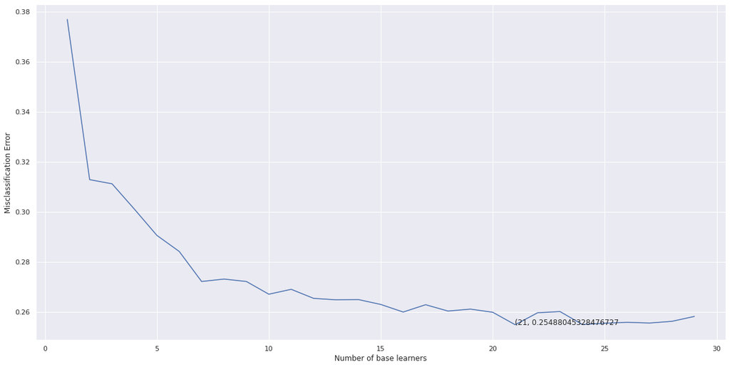

```python
# plotting the error as k increase

error = [1 - x for x in cv_score]
optimal_learners = base_ln[error.index(min(error))]

plt.plot(base_ln, error)
xy = (optimal_learners, min(error))
plt.annotate('(%s, %s' % xy, xy = xy, textcoords ='data')
plt.xlabel("Number of base learners")
plt.ylabel("Misclassification Error")
plt.show()
```

- Learner at 21,24, 25 provide less error. Let's go with 25 since it went straight line after that.

```python
# Training the best model and calculating accuracy on test data.
clf = RandomForestClassifier(n_estimators= 25)
clf.fit(X_train, y_train)
clf.score(X_test, y_test)
```

```
0.7566029143897997
```

```python
result = clf.predict(X_test)  # saving the prediction on test data as a result
```

```
[[2534  209   71]
 [ 417  397   70]
 [ 182  120  392]]
0.7566029143897997
```

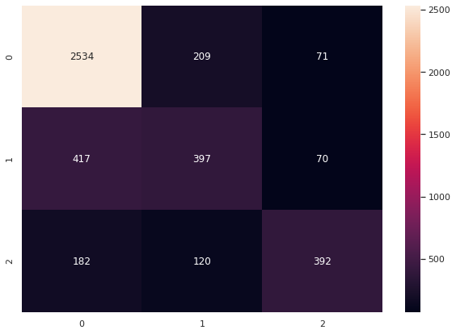

```python
# Print and plot confusion matrix to get an idea of how distribution of the prediction is, among all the classes.

import seaborn as sns
from sklearn import metrics
from sklearn.metrics import confusion_matrix

conf_mat = confusion_matrix(y_test, result)

print(conf_mat)

print(metrics.f1_score(y_test, result, average='micro'))
df_cm = pd.DataFrame(conf_mat, index=[i for i in "012"], columns=[i for i in '012'])

plt.figure(figsize=(10,7))
sns.heatmap(df_cm, annot=True, fmt='g')
```

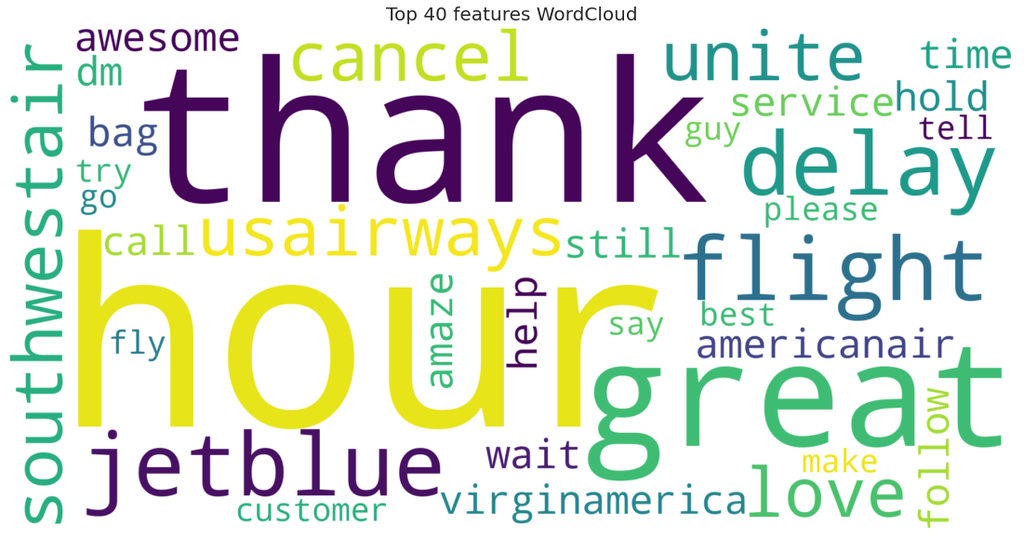

```python
# Rhe top 40 features and plot their word cloud
all_features = bow_vec.get_feature_names()
top_features =''
feat = clf.feature_importances_
features = np.argsort(feat)[::-1]
for i in features[0:40]:
  top_features+=all_features[i]
  top_features+=" "


from wordcloud import WordCloud
wordcloud = WordCloud(background_color ="white", colormap='viridis', width=2000, height=1000).generate(top_features)

# Display the generated image:
plt.imshow(wordcloud, interpolation='bilinear')
plt.figure(1, figsize=(14,11), frameon='equal')
plt.title('Top 40 features WordCloud', fontsize=20)
plt.axis("off")
plt.show()
```

- **thank, hour, great** are the most frequent tweeted by customers for this model.

### Term Frequency(TF) - Inverse Document Frequency (IDF)

```python
# Using TfidfVectorizer to convert text data to numbers.

from sklearn.feature_extraction.text import TfidfVectorizer

vectorizer = TfidfVectorizer(max_features=2000)
data_features = vectorizer.fit_transform(data1['text'])

data_features = data_features.toarray()
data_features.shape
```

```
(14640, 2000)
```

```python
# Split data into training and testing set.
X_train, X_test, y_train, y_test = train_test_split(data_features, labels, test_size=0.3, random_state=42)
```

```python
# Using Random Forest to build model for the classification of reviews.
# Also calculating the cross validation score.

forest = RandomForestClassifier(n_estimators=10, n_jobs=4)
forest = forest.fit(X_train, y_train)

print(forest)

print(np.mean(cross_val_score(forest, X_test, y_test, cv=5)))
```

```
RandomForestClassifier(bootstrap=True, ccp_alpha=0.0, class_weight=None,
                       criterion='gini', max_depth=None, max_features='auto',
                       max_leaf_nodes=None, max_samples=None,
                       min_impurity_decrease=0.0, min_impurity_split=None,
                       min_samples_leaf=1, min_samples_split=2,
                       min_weight_fraction_leaf=0.0, n_estimators=10, n_jobs=4,
                       oob_score=False, random_state=None, verbose=0,
                       warm_start=False)
0.7297324822937641
```

```python
# K - Fold Cross Validation
cv_scores = []
for b in base_ln:
  clf = RandomForestClassifier(n_estimators= b)
  scores = cross_val_score(clf, X_train, y_train, cv=5, scoring='accuracy')
  cv_scores.append(scores.mean())
```

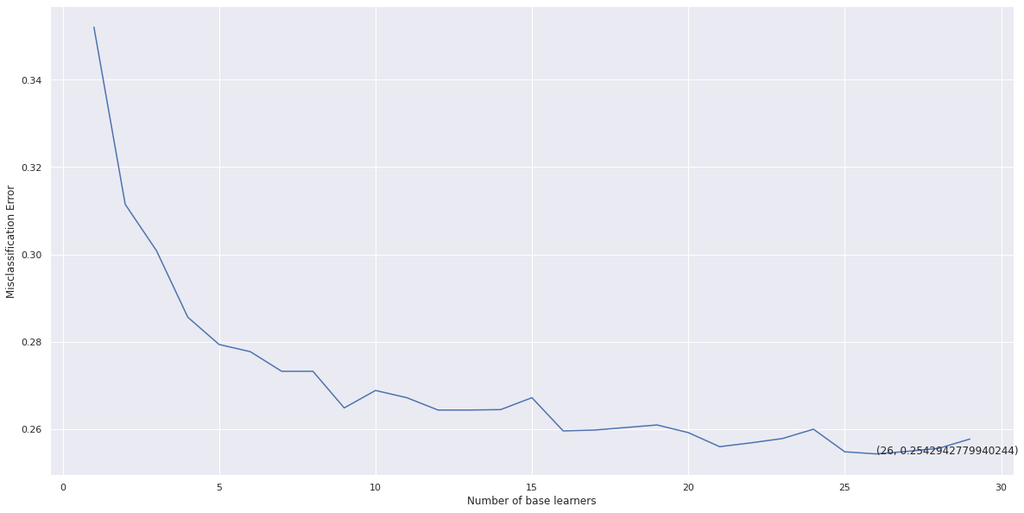

```python
# plotting the error as k increases
error = [1 - x for x in cv_scores]                      # error corresponds to each nu of estimator
optimal_learners = base_ln[error.index(min(error))]    # Selection of optimal nu of n_estimator corresponds to minimum error.
plt.plot(base_ln, error)                                # Plot between each nu of estimator and misclassification error

xy= (optimal_learners, min(error))
plt.annotate('(%s, %s)' % xy, xy = xy, textcoords='data')
plt.xlabel("Number of base learners")
plt.ylabel("Misclassification Error")
plt.show()
```

- 26 is the best number of learners.

```python
# Training the best model and calculation error on test data.
clf = RandomForestClassifier(n_estimators=26)
clf.fit(X_train, y_train)
clf.score(X_test, y_test)
```

```
0.76183970856102
```

```
[[2620  138   56]
 [ 469  353   62]
 [ 231   90  373]]
0.76183970856102
```

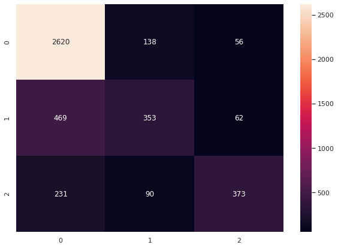

```python
# Print and plot Confusion matirx to get an idea of how the distribution of the prediction is, among all the classes.
result =  clf.predict(X_test)

conf_mat = confusion_matrix(y_test, result)

print(conf_mat)

print(metrics.f1_score(y_test, result,average='micro'))

df_cm = pd.DataFrame(conf_mat, index = [i for i in "012"],
                  columns = [i for i in "012"])
plt.figure(figsize = (10,7))
sns.heatmap(df_cm, annot=True, fmt='g')
```

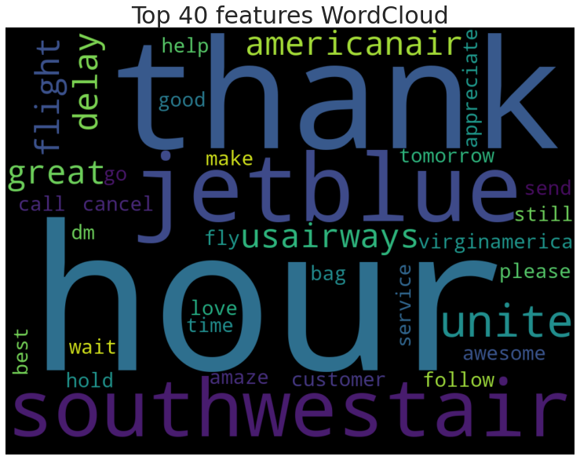

```python
all_features = vectorizer.get_feature_names()                                #Instantiate the feature from the vectorizer
Top_features=''                                                              #Addition of top 40 feature into top_feature after training the model
feat=clf.feature_importances_
features=np.argsort(feat)[::-1]
for i in features[0:40]:
    Top_features+=all_features[i]
    Top_features+=' '


from wordcloud import WordCloud
wordcloud = WordCloud(background_color="Black",width=1000,
                          height=750).generate(Top_features)

# Display the generated image:
plt.imshow(wordcloud, interpolation='bilinear')
plt.figure(1, figsize=(30, 30), frameon='equal')
plt.title('Top 40 features WordCloud', fontsize=30)
plt.axis("off")
plt.show()
```

- **thank,hour,jetblue** are the most frequent tweeted by customers in this model.

#### **Summary**:

- We used a dataset which has reviews in text format and their airline_sentiment of neutral, positive, and negative.
- The goal was to build a model for text-classification.
- We pre-processed the data using various techniques and libraries.
- We created Word Cloud plots of top 40 features
- The pre-processed data is converted to numbers (Vectorized [CountVectorizer, TF-IDF]), so that we can feed the data into the model.
- We trained the model and optimized the paramter(n_estimators), which lead to an increase the overall accuaracy.
- We predicted the results for the test data.
- The model can be improve by increasing max_features paramters in the vectorizer, using grid search cv to do hyperparmeter turning, and other pre-processing techniques to increase the overall accuracy even further.